# ADA Homework 3

**Challenge 1**

```r
library(curl)
library(readr)
```

```r
library(broom)
library(ggplot2)
library(ggpubr)
library(dplyr)
f <- curl("https://raw.githubusercontent.com/raneyej/ada-2021-datasets/main/KamilarAndCooperData.csv")
d <- read.csv(f, header = TRUE, sep = ",")
head(d)
```

```
##               Scientific_Name          Family          Genus      Species
## 1 Allenopithecus_nigroviridis Cercopithecidae Allenopithecus nigroviridis
## 2         Allocebus_trichotis Cercopithecidae      Allocebus    trichotis
## 3           Alouatta_belzebul        Atelidae       Alouatta     belzebul
## 4             Alouatta_caraya        Atelidae       Alouatta       caraya
## 5            Alouatta_guariba        Atelidae       Alouatta      guariba
## 6           Alouatta_palliata        Atelidae       Alouatta     palliata
##   Brain_Size_Species_Mean Brain_Size_Female_Mean   Brain_size_Ref
## 1                   58.02                  53.70 Isler et al 2008
## 2                      NA                     NA
## 3                   52.84                  51.19 Isler et al 2008
## 4                   52.63                  47.80 Isler et al 2008
## 5                   51.70                  49.08 Isler et al 2008
## 6                   49.88                  48.04 Isler et al 2008
##   Body_mass_male_mean Body_mass_female_mean Mass_Dimorphism
```

[output cut: 62 more lines]

Generate a linear model:

```r
bs_lm <- lm(WeaningAge_d ~ Brain_Size_Species_Mean, data = d)
summary(bs_lm)
```

```
##
## Call:
## lm(formula = WeaningAge_d ~ Brain_Size_Species_Mean, data = d)
##
## Residuals:
##     Min      1Q  Median      3Q     Max
## -505.38  -90.61  -34.74   48.83  483.77
##
## Coefficients:
##                         Estimate Std. Error t value Pr(>|t|)
## (Intercept)             132.4640    19.1788   6.907 3.69e-10 ***
## Brain_Size_Species_Mean   2.6371     0.1847  14.276  < 2e-16 ***
## ---
## Signif. codes:  0 '***' 0.001 '**' 0.01 '*' 0.05 '.' 0.1 ' ' 1
##
## Residual standard error: 150.5 on 107 degrees of freedom
##   (104 observations deleted due to missingness)
## Multiple R-squared:  0.6557, Adjusted R-squared:  0.6525
## F-statistic: 203.8 on 1 and 107 DF,  p-value: < 2.2e-16
```

```r
bs_lm_log <- lm(log(WeaningAge_d) ~ log(Brain_Size_Species_Mean), data = d)
summary(bs_lm_log)
```

```
##
## Call:
## lm(formula = log(WeaningAge_d) ~ log(Brain_Size_Species_Mean),
##     data = d)
##
## Residuals:
##     Min      1Q  Median      3Q     Max
## -1.0244 -0.2523 -0.0131  0.3225  0.9228
##
## Coefficients:
##                              Estimate Std. Error t value Pr(>|t|)
## (Intercept)                   3.36985    0.11671   28.88   <2e-16 ***
## log(Brain_Size_Species_Mean)  0.57116    0.03061   18.66   <2e-16 ***
## ---
## Signif. codes:  0 '***' 0.001 '**' 0.01 '*' 0.05 '.' 0.1 ' ' 1
##
## Residual standard error: 0.4108 on 107 degrees of freedom
##   (104 observations deleted due to missingness)
## Multiple R-squared:  0.765,  Adjusted R-squared:  0.7628
## F-statistic: 348.3 on 1 and 107 DF,  p-value: < 2.2e-16
```

Generate scatterplots for the models:

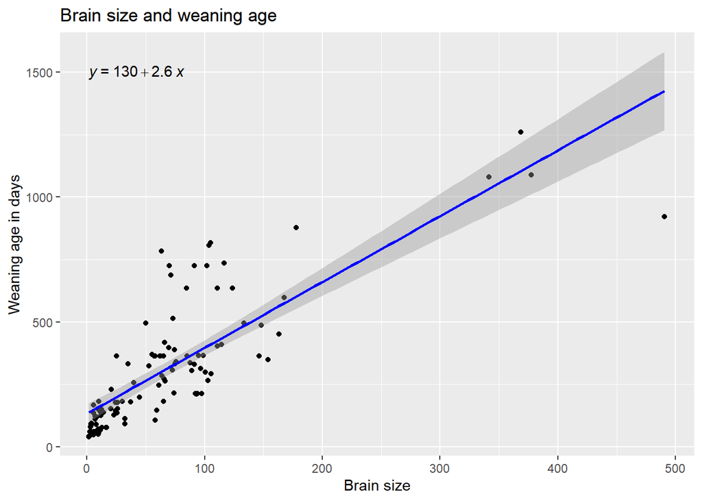

```r
brain_plot <- ggplot(data = d, aes(x = Brain_Size_Species_Mean, y = WeaningAge_d)) +
  geom_point() +
  geom_smooth(method = "lm", formula = y ~ x, color = "blue") +
  stat_regline_equation(label.y = 1500, aes(label = ..eq.label..)) +
  ggtitle(label = "Brain size and weaning age") + xlab("Brain size") + ylab("Weaning age in days")
brain_plot
```

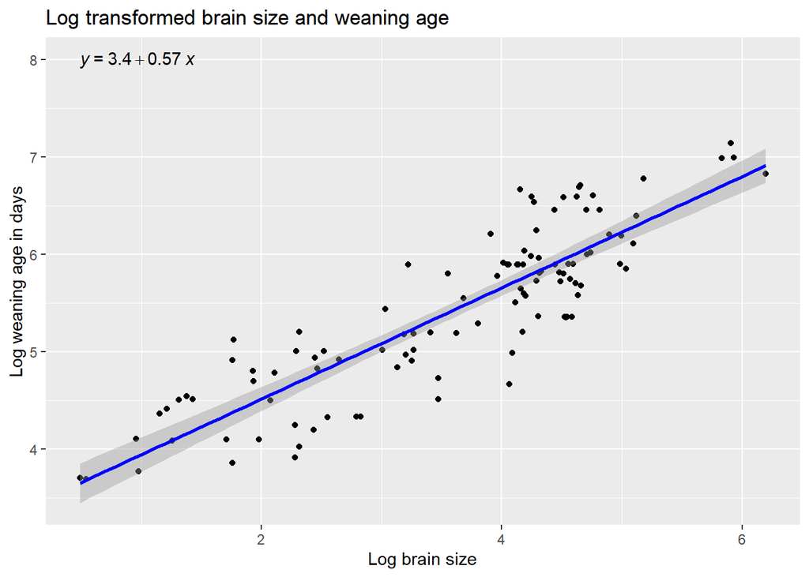

```r
log_brain_plot <- ggplot(data = d, aes(x = log(Brain_Size_Species_Mean), y = log(WeaningAge_d))) +
  geom_point() +
  geom_smooth(method = "lm", formula = y ~ x, color = "blue") +
  stat_regline_equation(label.y = 8, aes(label = ..eq.label..)) +
  ggtitle(label = "Log transformed brain size and weaning age") + xlab("Log brain size") + ylab("Log weaning age in days")
log_brain_plot
```

Coefficients:

```r
tidy(bs_lm)
```

```
## # A tibble: 2 x 5
##   term                    estimate std.error statistic  p.value
##   <chr>                      <dbl>     <dbl>     <dbl>    <dbl>
## 1 (Intercept)               132.      19.2        6.91 3.69e-10
## 2 Brain_Size_Species_Mean     2.64     0.185     14.3  1.59e-26
```

```r
tidy(bs_lm_log)
```

```
## # A tibble: 2 x 5
##   term                         estimate std.error statistic  p.value
##   <chr>                           <dbl>     <dbl>     <dbl>    <dbl>
## 1 (Intercept)                     3.37     0.117       28.9 2.53e-52
## 2 log(Brain_Size_Species_Mean)    0.571    0.0306      18.7 1.99e-35
```

```r
beta0 <- tidy(bs_lm) %>%
  filter(term == "(Intercept)") %>%
  pull(estimate)
beta0
```

```
## [1] 132.464
```

```r
beta1 <- tidy(bs_lm_log) %>%
  filter(term == "log(Brain_Size_Species_Mean)") %>%
  pull(estimate)
beta1
```

```
## [1] 0.57116
```

Hypothesis test:

```r
beta1 == 0
```

```
## [1] FALSE
```

```r
beta1!=0
```

```
## [1] TRUE
```

The slope estimate for the regular model is 2.64, and the slope estimate for the log-transformed model is 0.57. Both p-values are much less than 0.001 (1.59e-26 and 1.99e-35, respectively), so we can reject the null hypothesis and assume that there is a relationship between brain size and weaning age.

Confidence intervals:

```r
ci_beta1 <- predict(bs_lm_log, newdata = data.frame(Brain_Size_Species_Mean = 2.64), interval = "confidence", level = 0.90)
ci_beta1
```

```
##        fit      lwr     upr
## 1 3.924316 3.776153 4.07248
```

```r
ci_bs_lm <- predict(bs_lm, newdata = data.frame(Brain_Size_Species_Mean <- d$Brain_Size_Species_Mean), interval = "confidence", level = 0.90)
ci_bs_lm
```

```
##           fit       lwr       upr
## 1    285.4690  261.3345  309.6034
## 2          NA        NA        NA
## 3    271.8088  247.4128  296.2047
## 4    271.2550  246.8463  295.6636
## 5    268.8025  244.3355  293.2694
## 6    264.0029  239.4127  288.5931
## 7    267.2993  242.7950  291.8036
## 8    278.0851  253.8218  302.3483
## 9    186.9730  158.9221  215.0240
## 10         NA        NA        NA
## 11   175.4489  146.6757  204.2220
## 12         NA        NA        NA
## 13         NA        NA        NA
## 14   176.8993  148.2194  205.5791
```

[output cut: 199 more lines]

```r
ci_bs_lm_log <- predict(bs_lm_log, newdata = data.frame(Brain_Size_Species_Mean <- d$Brain_Size_Species_Mean), interval = "confidence", level = 0.90)
ci_bs_lm_log
```

```
##          fit      lwr      upr
## 1   5.689206 5.619675 5.758737
## 2         NA       NA       NA
## 3   5.635791 5.567747 5.703835
## 4   5.633517 5.565529 5.701504
## 5   5.623334 5.555594 5.691074
## 6   5.602865 5.535587 5.670143
## 7   5.617002 5.549409 5.684594
## 8   5.660955 5.592247 5.729663
## 9   5.099709 5.028472 5.170946
## 10        NA       NA       NA
## 11  4.964048 4.887187 5.040909
## 12        NA       NA       NA
## 13        NA       NA       NA
## 14  4.983002 4.907017 5.058988
```

[output cut: 199 more lines]

```r
ci_array <- cbind(d$Brain_Size_Species_Mean, ci_bs_lm)
ci_df <- as.data.frame(ci_array)
ci_df
```

```
##         V1       fit       lwr       upr
## 1    58.02  285.4690  261.3345  309.6034
## 2       NA        NA        NA        NA
## 3    52.84  271.8088  247.4128  296.2047
## 4    52.63  271.2550  246.8463  295.6636
## 5    51.70  268.8025  244.3355  293.2694
## 6    49.88  264.0029  239.4127  288.5931
## 7    51.13  267.2993  242.7950  291.8036
## 8    55.22  278.0851  253.8218  302.3483
## 9    20.67  186.9730  158.9221  215.0240
## 10      NA        NA        NA        NA
## 11   16.30  175.4489  146.6757  204.2220
## 12      NA        NA        NA        NA
## 13      NA        NA        NA        NA
## 14   16.85  176.8993  148.2194  205.5791
```

[output cut: 199 more lines]

```r
x1 <- d$Brain_Size_Species_Mean
x1
```

```
##   [1]  58.02     NA  52.84  52.63  51.70  49.88  51.13  55.22  20.67     NA
##  [11]  16.30     NA     NA  16.85     NA   6.92 117.02 114.24 105.09 103.85
##  [21]   9.86   7.95 116.72 110.68  76.00  68.77     NA     NA     NA     NA
##  [31]     NA  11.43   7.95     NA     NA     NA   7.24     NA   7.32   4.17
##  [41]  65.45  66.63  72.93  69.84  66.09 116.43  99.07 105.99  94.68  70.10
##  [51]  59.58  57.39  65.26  62.61  65.40  65.90  74.20  71.33  61.84  65.97
##  [61]  71.13  55.08  59.56     NA     NA  61.45   5.81   2.60  48.33  65.00
##  [71]  62.58  64.91  77.70  74.39  73.83  74.90  73.07  44.85  97.73  21.45
##  [81]  22.10     NA  20.65  25.77  24.51  20.17  26.23  25.40     NA   5.53
##  [91]   4.62   3.71   3.96   2.65   3.51 491.27 490.41     NA  14.09  13.80
## [101]     NA  91.16  87.99 101.87     NA  85.13  84.69  34.81  96.50  22.90
## [111]  11.84     NA  12.83   6.70   7.25   6.87     NA     NA   8.25  93.97
## [121] 101.59   6.34   5.87 100.70  90.46  82.00  63.98 102.92  85.60  88.98
## [131] 105.59  94.90     NA  74.87  85.00  69.70  93.20     NA 148.00 153.88
## [141]   1.63     NA   1.72  37.35   5.80  92.30     NA 119.38     NA  13.49
## [151]  10.13     NA  11.78  11.50 341.29 368.35 167.42 163.19 146.17 178.00
## [161]  12.42   6.68  63.59  57.25     NA     NA  70.95     NA  32.26 389.50
## [171] 377.38  80.30  64.85  52.60  30.19  30.15  39.80  39.49     NA  26.21
## [181]  91.41     NA     NA 117.76     NA   7.94  10.14     NA   9.70   9.78
## [191]  11.09   9.48   9.76     NA     NA  25.07  24.14 110.93 123.50   3.16
## [201]     NA   3.36 133.33     NA  57.86  81.30  84.60  62.12  72.84 103.64
## [211]  61.29  31.08  32.12
```

```r
x2 <- log(x1)
x2
```

```
##   [1] 4.0607878        NA 3.9672685 3.9632863 3.9454578 3.9096201 3.9343714
##   [8] 4.0113252 3.0286834        NA 2.7911651        NA        NA 2.8243507
##  [15]        NA 1.9344158 4.7623449 4.7383015 4.6548171 4.6429476 2.2884862
##  [22] 2.0731719 4.7597779 4.7066432 4.3307333 4.2307676        NA        NA
##  [29]        NA        NA        NA 2.4362415 2.0731719        NA        NA
##  [36]        NA 1.9796212        NA 1.9906103 1.4279160 4.1812865 4.1991549
##  [43] 4.2895001 4.2462069 4.1910174 4.7572902 4.5958267 4.6633448 4.5505028
##  [50] 4.2499228 4.0873199 4.0498701 4.1783793 4.1369250 4.1805223 4.1881384
##  [57] 4.3067642 4.2673170 4.1245504 4.1892001 4.2645092 4.0087867 4.0869842
##  [64]        NA        NA 4.1182238 1.7595806 0.9555114 3.8780525 4.1743873
##  [71] 4.1364457 4.1730017 4.3528553 4.3093215 4.3017652 4.3161539 4.2914179
##  [78] 3.8033236 4.5822086 3.0657246 3.0955776        NA 3.0277153 3.2492110
##  [85] 3.1990812 3.0041964 3.2669038 3.2347492        NA 1.7101878 1.5303947
##  [92] 1.3110319 1.3762440 0.9745596 1.2556160 6.1969939 6.1952418        NA
##  [99] 2.6454653 2.6246686        NA 4.5126162 4.4772232 4.6236975        NA
```

[output cut: 16 more lines]

```r
ci_array2 <- cbind(x2, ci_bs_lm_log)
ci_df2 <- as.data.frame(ci_array2)
ci_df2
```

```
##            x2      fit      lwr      upr
## 1   4.0607878 5.689206 5.619675 5.758737
## 2          NA       NA       NA       NA
## 3   3.9672685 5.635791 5.567747 5.703835
## 4   3.9632863 5.633517 5.565529 5.701504
## 5   3.9454578 5.623334 5.555594 5.691074
## 6   3.9096201 5.602865 5.535587 5.670143
## 7   3.9343714 5.617002 5.549409 5.684594
## 8   4.0113252 5.660955 5.592247 5.729663
## 9   3.0286834 5.099709 5.028472 5.170946
## 10         NA       NA       NA       NA
## 11  2.7911651 4.964048 4.887187 5.040909
## 12         NA       NA       NA       NA
## 13         NA       NA       NA       NA
## 14  2.8243507 4.983002 4.907017 5.058988
```

[output cut: 199 more lines]

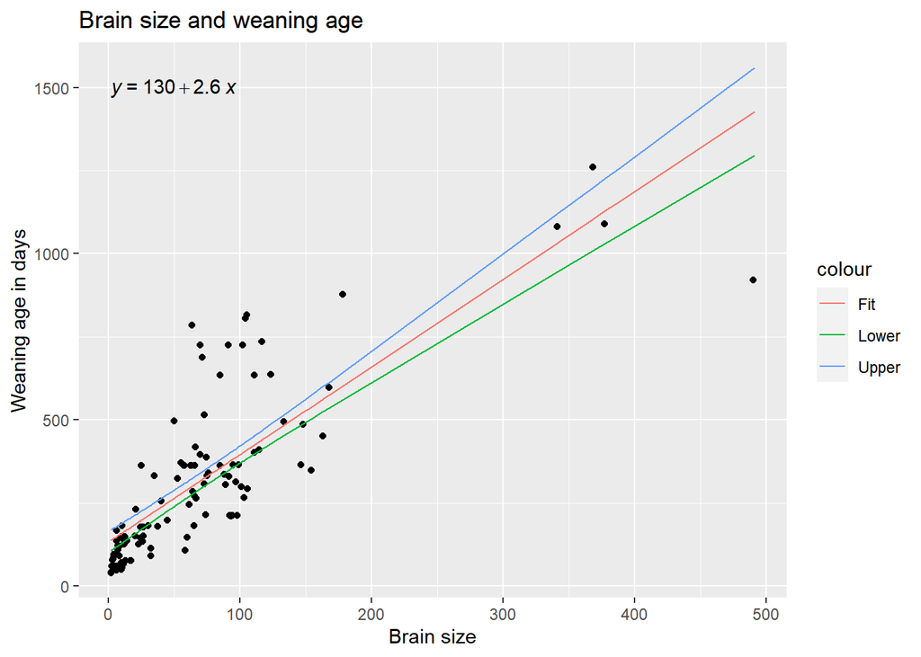

```r
ci_plot1 <- ggplot(data = d, aes(x = Brain_Size_Species_Mean, y = WeaningAge_d)) +
  geom_point() +
  geom_line(data = ci_df, aes( x = V1, y = fit, color = "Fit")) +
  geom_line(data = ci_df, aes(x = V1, y = lwr, color = "Lower")) +
  geom_line(data = ci_df, aes(x = V1, y = upr, color = "Upper")) +
  stat_regline_equation(label.y = 1500, aes(label = ..eq.label..)) +
  ggtitle(label = "Brain size and weaning age") + xlab("Brain size") + ylab("Weaning age in days")
ci_plot1
```

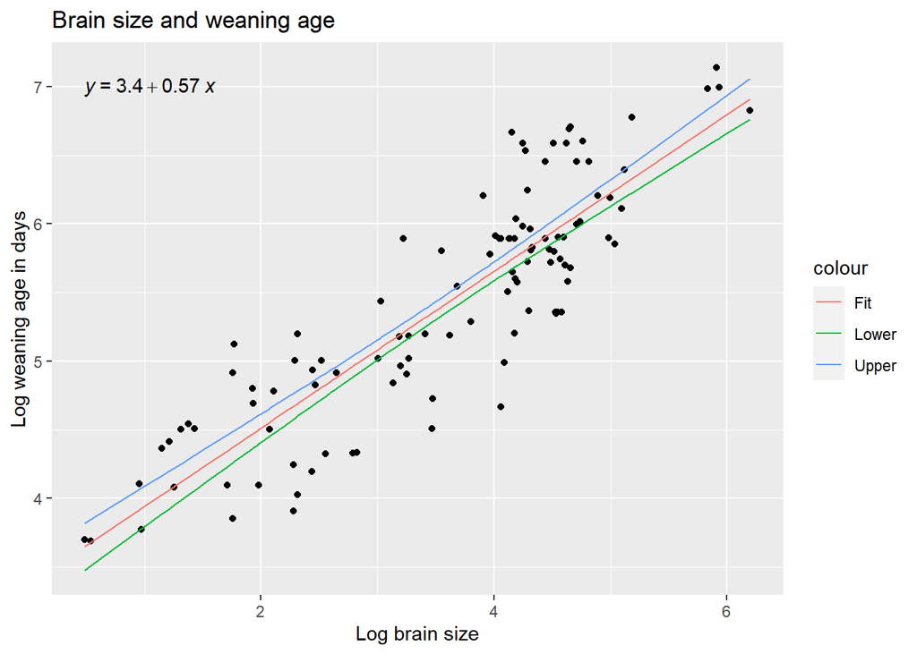

```r
ci_plot2 <- ggplot(data = d, aes(x = log(Brain_Size_Species_Mean), y = log(WeaningAge_d))) +
  geom_point() +
  geom_line(data = ci_df2, aes( x = x2, y = fit, color = "Fit")) +
  geom_line(data = ci_df2, aes(x = x2, y = lwr, color = "Lower")) +
  geom_line(data = ci_df2, aes(x = x2, y = upr, color = "Upper")) +
  stat_regline_equation(label.y = 7, aes(label = ..eq.label..)) +
  ggtitle(label = "Brain size and weaning age") + xlab("Log brain size") + ylab("Log weaning age in days")
ci_plot2
```

Predict weaning age for a brain size of 750g:

```r
prediction <- predict(bs_lm, newdata = data.frame(Brain_Size_Species_Mean = 750), interval = "prediction", level = 0.90)
prediction
```

```
##        fit      lwr      upr
## 1 2110.294 1783.832 2436.757
```

The predicted age of weaning for a primate with a brain size of 750 grams is 2,110 days, or about 6 years. I am not confident in this estimate, because although their is a relationship between brain size and weaning age, 750 grams is much larger than the largest average brain size in the data set (491 grams). Because it is so much larger, it is possible that the model might not predict weaning age accurately.

I think that the transformed model is better, because the relationship between brain size and weaning age is much more obvious than in the regular model.

*Challenge 2*

```r
gs_lm_log <-  lm(log(MeanGroupSize) ~ log(Body_mass_female_mean), data = d)
gs_lm_log
```

```
##
## Call:
## lm(formula = log(MeanGroupSize) ~ log(Body_mass_female_mean),
##     data = d)
##
## Coefficients:
##                (Intercept)  log(Body_mass_female_mean)
##                    -1.7773                      0.5063
```

```r
summary(gs_lm_log)
```

```
##
## Call:
## lm(formula = log(MeanGroupSize) ~ log(Body_mass_female_mean),
##     data = d)
##
## Residuals:
##      Min       1Q   Median       3Q      Max
## -2.85428 -0.66210  0.03604  0.63941  2.51998
##
## Coefficients:
##                            Estimate Std. Error t value Pr(>|t|)
## (Intercept)                -1.77726    0.43752  -4.062 8.06e-05 ***
## log(Body_mass_female_mean)  0.50628    0.05563   9.102 8.08e-16 ***
## ---
## Signif. codes:  0 '***' 0.001 '**' 0.01 '*' 0.05 '.' 0.1 ' ' 1
##
## Residual standard error: 0.9373 on 140 degrees of freedom
##   (71 observations deleted due to missingness)
## Multiple R-squared:  0.3717, Adjusted R-squared:  0.3673
## F-statistic: 82.84 on 1 and 140 DF,  p-value: 8.078e-16
```

```r
tidy(gs_lm_log)
```

```
## # A tibble: 2 x 5
##   term                       estimate std.error statistic  p.value
##   <chr>                         <dbl>     <dbl>     <dbl>    <dbl>
## 1 (Intercept)                  -1.78     0.438      -4.06 8.06e- 5
## 2 log(Body_mass_female_mean)    0.506    0.0556      9.10 8.08e-16
```

The slope is 0.506, and the y-intercept is -1.78.

```r
gs_beta0 <- tidy(gs_lm_log) %>%
  filter(term == "(Intercept)") %>%
  pull(estimate)
gs_beta0
```

```
## [1] -1.777258
```

```r
gs_beta1 <- tidy(gs_lm_log) %>%
  filter(term == "log(Body_mass_female_mean)") %>%
  pull(estimate)
gs_beta1
```

```
## [1] 0.5062813
```

```r
boot_betas <- data.frame(gs_beta0_boot = 1:1000, gs_beta1_boot = 1:1000)
n = nrow(d)
for(i in 1:1000) {
  s <- sample_n(d, size = n, replace = TRUE)
  gs_boot <- lm(log(MeanGroupSize) ~ log(Body_mass_female_mean), data = s)
  betas <- gs_boot$coefficients
  gs_beta0_boot <- as.numeric(betas[1])
  gs_beta1_boot <- as.numeric(betas[2])
  boot_betas$gs_beta0_boot[[i]] <- gs_beta0_boot
  boot_betas$gs_beta1_boot[[i]] <- gs_beta1_boot
}
boot_betas
```

```
##      gs_beta0_boot gs_beta1_boot
## 1      -1.22471964     0.4613501
## 2      -1.96223611     0.5396054
## 3      -1.01372787     0.4081962
## 4      -1.24858926     0.4352240
## 5      -1.55753640     0.4709253
## 6      -0.64470955     0.3642376
## 7      -1.88302121     0.5114600
## 8      -2.29935865     0.5813720
## 9      -2.00042187     0.5385257
## 10     -2.28548170     0.5728684
## 11     -2.09335828     0.5517846
## 12     -1.52446411     0.4791701
## 13     -1.93261947     0.5173172
## 14     -1.48621550     0.4595549
```

[output cut: 986 more lines]

Histograms of distributions:

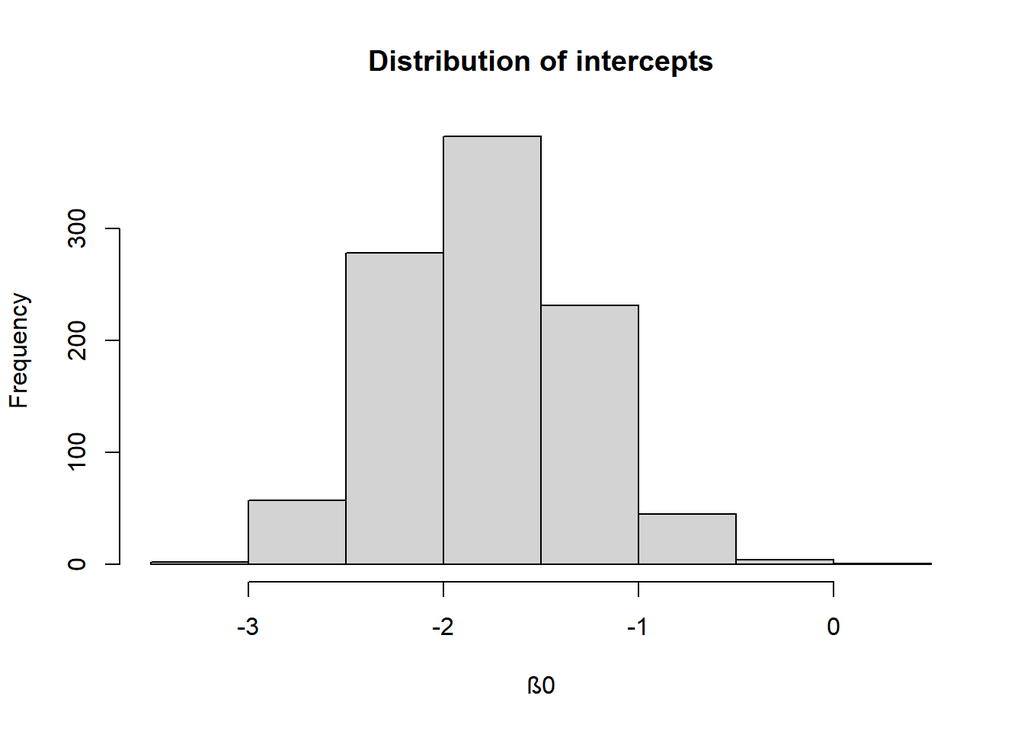

```r
hist_beta0 <- hist(boot_betas$gs_beta0_boot, main = "Distribution of intercepts", xlab = "β0")
```